# DAR CW 1

# 13191103

### 1. Statistical learning methods

For each of parts (a) through (d), indicate whether we would generally expect the performance of a flexible statistical learning method to be better or worse than an inflexible method. Justify your answer

#### (a) The number of predictors p is extremely large, and the number of observations n is small.

An inflexible statistical model would be better for this problem. An inflexible model will keep the variance lower than a flexible model and there is less chance of overfitting with an inflexible model since the number of observations is low.

#### (b) The sample size n is extremely large, and the number of predictors p is small.

A flexible model would work better in this scenario. Since there are a large number of observations, we do not have to worry as much about high variance and a flexible model usually reduces bias. The large sample size allows less chance of us overfitting the model.

#### (c) The relationship between the predictors and response is highly non-linear.

A flexible model since the relationship is non-linear. It will also provide us with more accurate estimates.

#### (d) The standard deviation of the error terms, i.e. _ = sd("), is extremely high.

An inflexible model would work better here. The flexible model will capture the high variances of all the data points potentially giving us less accurate estimates. High standard deviation could also potentially mean outliers/noise in the data set which the flexible model will take into account.

### 2. Bayes’ Rule

#### Given a dataset including 20 observations (S_1, …. S_20) about the temperature (i.e. hot or cool) for playing golf (i.e. yes or no), you are required to use the Bayes’ rule to calculate by hand the probability of playing golf according to the temperature, i.e. P(Play Golf | Temperature).

|  | S_1 | S_2 | S_3 | S_4 | S_5 | S_6 | S_7 | S_8 | S_9 | S_10 |
| --- | --- | --- | --- | --- | --- | --- | --- | --- | --- | --- |
| Temperature | cool | hot | hot | hot | cool | cool | hot | cool | hot | hot |
| Play Golf | yes | no | yes | no | yes | yes | no | yes | no | yes |

|  | S_11 | S_12 | S_13 | S_14 | S_15 | S_16 | S_17 | S_18 | S_19 | S_20 |
| --- | --- | --- | --- | --- | --- | --- | --- | --- | --- | --- |
| Temperature | hot | hot | hot | cool | hot | hot | cool | cool | cool | hot |
| Play Golf | no | no | yes | no | no | no | yes | no | no | no |

P(Temp = hot) = 12/20 = 0.6

P(Temp = cool) = 8/20 = 0.4

P(Golf = yes) = 8/20 = 0.4

P(Golf = no) = 12/20 = 0.6

P(hot | yes) = 3/8 = 0.375

P(cool | yes) = 5/8 = 0.625

P(hot | no) = 9/12 = 0.75

P(cool | no) = 3/12 = 0.25

P(Golf|Temp) = P(Temp|Golf)P(Golf)/P(Temp)

True positive => P(yes | hot) = (0.375 x 0.4)/0.6 = 0.25

False negative => P(yes | cool) = (0.625 x 0.4)/0.4 = 0.625

False positive => P(no | hot) = (0.75 x x0.6)/0.6 = 0.75

True negative => P(no | cool) = (0.25 x 0.6)/0.4 = 0.375

### 3. Descriptive Analysis

This question involves the Auto dataset included in the “ISLR” package.

#### Load the data

```r
library(ISLR)
head(Auto)
```

```
  mpg cylinders displacement horsepower weight acceleration year origin
1  18         8          307        130   3504         12.0   70      1
2  15         8          350        165   3693         11.5   70      1
3  18         8          318        150   3436         11.0   70      1
4  16         8          304        150   3433         12.0   70      1
5  17         8          302        140   3449         10.5   70      1
6  15         8          429        198   4341         10.0   70      1
                       name
1 chevrolet chevelle malibu
2         buick skylark 320
3        plymouth satellite
4             amc rebel sst
5               ford torino
6          ford galaxie 500
```

```r
data <- Auto
str(data)
```

```
'data.frame':   392 obs. of  9 variables:
 $ mpg         : num  18 15 18 16 17 15 14 14 14 15 ...
 $ cylinders   : num  8 8 8 8 8 8 8 8 8 8 ...
 $ displacement: num  307 350 318 304 302 429 454 440 455 390 ...
 $ horsepower  : num  130 165 150 150 140 198 220 215 225 190 ...
 $ weight      : num  3504 3693 3436 3433 3449 ...
 $ acceleration: num  12 11.5 11 12 10.5 10 9 8.5 10 8.5 ...
 $ year        : num  70 70 70 70 70 70 70 70 70 70 ...
 $ origin      : num  1 1 1 1 1 1 1 1 1 1 ...
 $ name        : Factor w/ 304 levels "amc ambassador brougham",..: 49 36 231 14 161 141 54 223 241 2 ...
```

```r
quant = c("mpg", "cylinders", "displacement", "horsepower", "weight", "acceleration")
```

Quantitative: are mpg, cylinders, displacement, horsepower, weight, acceleration Qualitative: name, year, origin

#### (b) What is the range of each quantitative predictor? You can answer this using the range() function.

```r
for(i in quant){
cat(i,range(data[i]), '\n')
}
```

```
mpg 9 46.6
cylinders 3 8
displacement 68 455
horsepower 46 230
weight 1613 5140
acceleration 8 24.8
```

#### (c) What is the median and variance of each quantitative predictor?

```r
for(i in quant){
cat(i,'\n', 'median: ', sapply(data[i],median),'\n', 'variance: ',sapply(data[i],sd),'\n')
}
```

```
mpg
 median:  22.75
 variance:  7.805007
cylinders
 median:  4
 variance:  1.705783
displacement
 median:  151
 variance:  104.644
horsepower
 median:  93.5
 variance:  38.49116
weight
 median:  2803.5
 variance:  849.4026
acceleration
 median:  15.5
 variance:  2.758864
```

#### (d) Now remove the 11th through 79th observations (inclusive) in the dataset. What is the range, median, and variance of each predictor in the subset of the data that remains?

```r
data <- data[-c(11:79), ]
for(i in quant){
cat(i,'\n', 'median: ', sapply(data[i],median),'\n', 'variance: ',sapply(data[i],sd),'\n')
}
```

```
mpg
 median:  23.9
 variance:  7.832649
cylinders
 median:  4
 variance:  1.657992
displacement
 median:  144
 variance:  100.1613
horsepower
 median:  90
 variance:  35.94408
weight
 median:  2789
 variance:  810.8619
acceleration
 median:  15.5
 variance:  2.701154
```

#### (e) Using the full data set, investigate the relationship between individual predictors with the target response gas mileage (mpg) graphically. Comment on your findings.

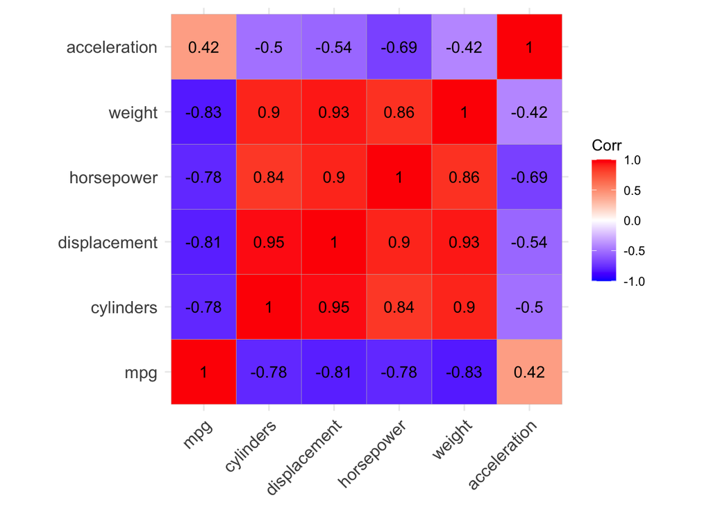

```r
library(dplyr)
library(ggcorrplot)
data <- Auto
correlation <-cor(select(data,all_of(quant)))
ggcorrplot(correlation, lab=TRUE)
```

Negative correlations are in blue while positive in red. We can clearly see that cylinders, displacement, horsepower and weight are negatively correlated with mpg. This means as the mentioned variables increase, there is a loss in mpg. On the other hand, Acceleration has a positive effect on mpg, as acceleration increases so does miles per gallon.

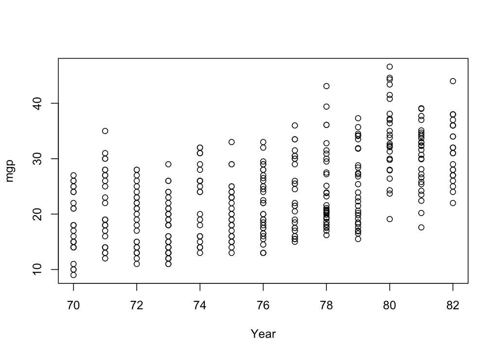

```r
plot( data$mpg ~ data$year , xlab ="Year", ylab="mgp")
```

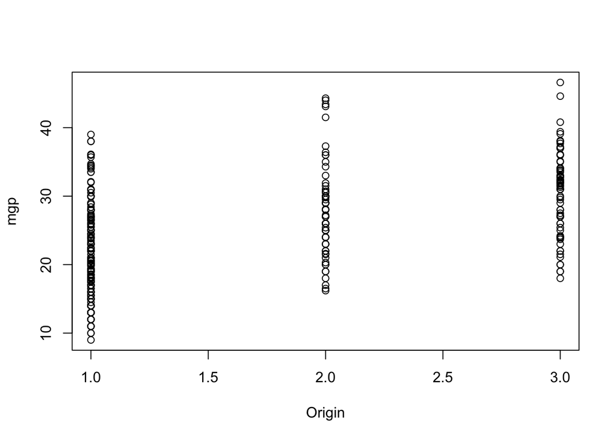

```r
plot( data$mpg ~ data$origin , xlab ="Origin", ylab="mgp")
```

From the categorical variables, we find that the newer/more recent the car, the better the mileage. Origin 3 looks to have the best mpg, and Origin 1 is the worst performing region in that metric.